# MultiStart parameter sensitivity analysis

Pratik A. Khare

2026-01-05

## A brief note on the data used in this document

♦ MultiStart_KOM_output and MultiStart_SOM_output are structures containing the final parameter values, fval, and initial guesses for each of the 20 MultiStart iterations, organized sequentially by the order in which initial guesses were generated.  
♦ Params_KOM_final and Params_SOM_final are vectors (45x1) of the final parameters generated in the code described in the manuscript.

## Fval (objective value) comparison between KOM and SOM

First, we will just see the distribution of the fval for the KOM and SOM side-by-side via a boxplot:

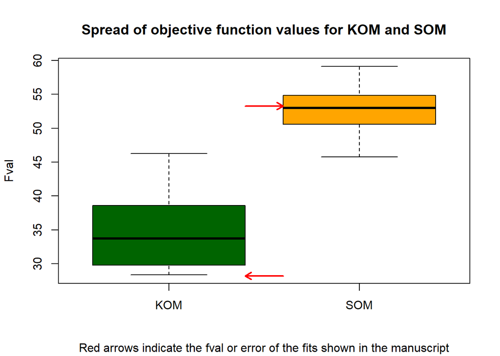

As seen in the boxplot, the KOM and SOM have distinctly different fval values.  
→ The range for KOM fvals is 28.347333, 46.2775639  
→ The range for SOM fvals is 45.7765499, 59.1114534

The KOM in the manuscript actually converges to the lowest error when initialized to within +-20% of the original initial guesses!

The difference between the fvals for the KOM and SOM is significant, as seen by the p-value: 2.0577011^{-13}

We can also see the plots of the fvals for the KOM and SOM as a scatter plot, alongwith where the final fval was dicovered for the simulation described in the paper:

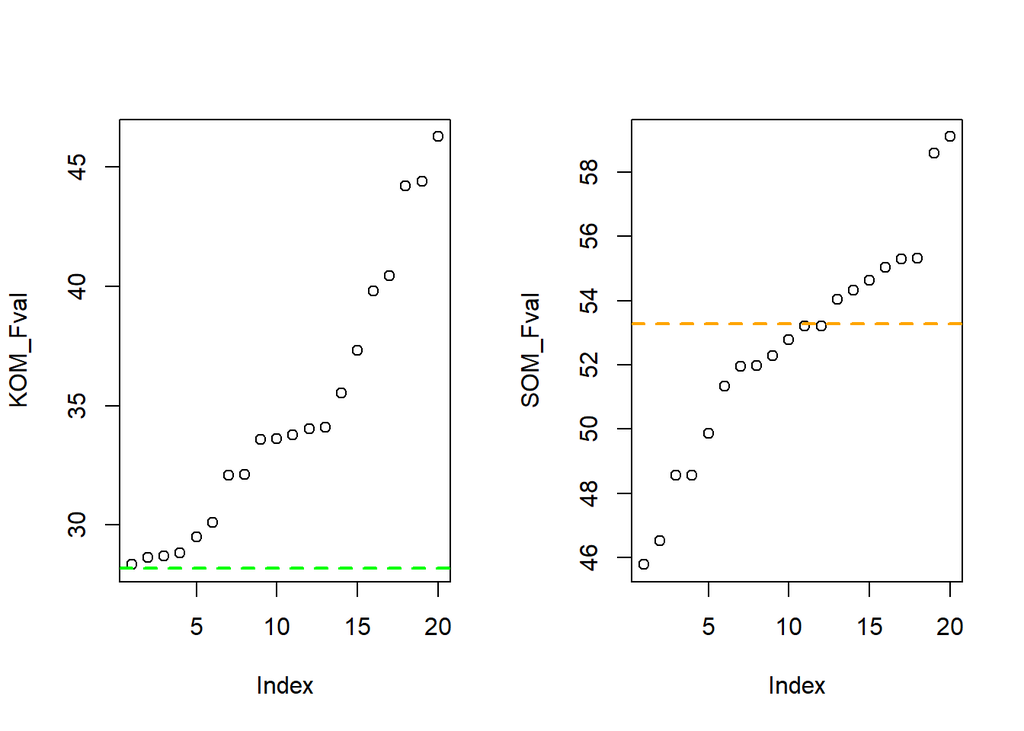

## Euclidean distance between the final parameters for each Multistart iteration and the fianl params in the paper

Next, we will compute the pairwise Euclidean distance between each final parameter value from the 20 MultiStart iterations and the final parameter set that is optimized and used in the paper.

Why do we use Euclidean distance? It is the most common distance measure and is merely the distance between two points. Since the major disadvantage of Euclidean distance—lack of normalization—is not a problem due to the already log-normalized parameters, it makes Euclidean the ideal distance measure.

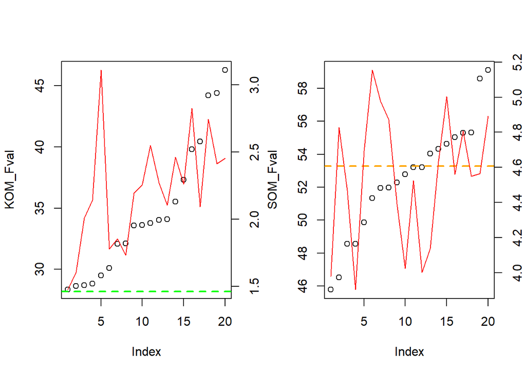

## The observations are:

♦ KOM: Smaller fvals tend to have parameters closer to the final KOM parameters shown in the paper. There is one outlier though.  
♦ SOM: There doesn’t seem to be a relationship between the fval and the parameter distances.

## What these observations tell us:

♦ KOM: The found solution (from the paper) seems to be optimal with a single dominant minima in which our solution lies.  
♦ SOM: The objective landscape is potentially flat, and there is no set parameter basin that yields low fval and multiple parameters seem to be giving similar fvals. Given that the kinetic parameters are only loosely dictating the fluxes and therefore the concentrations (objective finction), I’d say this is expected.